# RNAseq pipeline - Bioconductor

Ricardo Gonzalo Sanz y Alex Sánchez-Pla

07 Juni, 2020

```r
# lectura de los ficheros
targets <- read.csv("./input/targets.csv", header=TRUE, sep=",")
counts  <- read.csv("./input/counts.csv",  header=TRUE, sep=";",row.names = 1)

# comprobación de las dimensiones
dim(targets)
```

```
## [1] 292   9
```

```r
dim(counts)
```

```
## [1] 56202   292
```

```r
# seleccionar aleatóriamente 10 muestras de cada grupo (NIT, SFI y ELI) del fichero "targets"
set.seed(12345)
sample_NIT <- sample(targets[which(targets$Group=="NIT"),"Sample_Name"],10)
sample_SFI <- sample(targets[which(targets$Group=="SFI"),"Sample_Name"],10)
sample_ELI <- sample(targets[which(targets$Group=="ELI"),"Sample_Name"],10)

# cambiar los guiones por puntos en el nombre de las muestras para poder buscar en el fichero "counts"
sample_NIT <- gsub("[-]",".",sample_NIT)
sample_SFI <- gsub("[-]",".",sample_SFI)
sample_ELI <- gsub("[-]",".",sample_ELI)

counts_NTI <- counts[,sample_NIT]
counts_SFI <- counts[,sample_SFI]
counts_ELI <- counts[,sample_ELI]

# fichero de contaje: cts
cts0 <- cbind(counts_NTI,counts_SFI,counts_ELI)
#cts0 <- cbind(counts_NTI,counts_SFI)
muestra <- c(paste("NIT",1:10,sep=""),paste("SFI",1:10,sep=""),paste("ELI",1:10,sep=""))
#muestra <- c(paste("NIT",1:10,sep=""),paste("SFI",1:10,sep=""))

colnames(cts0) <- muestra

# fichero de información de las muestras
coldata <- data.frame(muestra,type=c(rep("NIT",10),rep("SFI",10),rep("ELI",10)))
coldata$type <- factor(coldata$type, levels = c("NIT","SFI","ELI"))
#coldata <- data.frame(muestra,type=c(rep("NIT",10),rep("SFI",10)))
#coldata$type <- factor(coldata$type, levels = c("NIT","SFI"))
```

Tenemos ya nuestros ficheros disponibles, pero podemos ver que muchas filas (genes) no tienen ningún o poco contaje en ninguna de las muestras. Esto lo podemos comprobar considerando el máximo valor por fila. También veremos el máximo contaje por muestra, para ver en que rango se mueve sus respectivos máximos.

```r
contaje.max.gen <- apply(cts0,1,max)
summary(contaje.max.gen)
```

```
##    Min. 1st Qu.  Median    Mean 3rd Qu.    Max.
##       0       1      10    2385     567 3625535
```

```r
contaje.max.muestra <- apply(cts0,2,max)
summary(contaje.max.muestra)
```

```
##    Min. 1st Qu.  Median    Mean 3rd Qu.    Max.
##  372374 1009662 1456550 1689300 2254208 3625535
```

Podemos observar que hay genes que tienen el máximo contaje en 0 o 1. Si los descartamos nos desprenderíamos de al menos el 25% de los genes. Viendo el máximo por muestra, notamos que el valor máximo menor está en 372374. Por lo que quitar los genes con puntajes máximos de 0 o 1 no debería afectar al resultado del análisis. Además, solo estaremos interesados en genes que estén al menos en dos muestras.

```r
keep1 <- which(contaje.max.gen>1) #genes con al menos un contaje mayor que 1
dim(cts0)
```

```
## [1] 56202    30
```

```r
cts1 <- cts0[keep1,]
cts1 <- na.omit(cts1)
dim(cts1)
```

```
## [1] 41369    30
```

```r
# función para calcular la cantidad de no ceros en un vector
cant.noceros <- function(vector) {
  cont <- 0
  for (i in 1:length(vector)){
    if (vector[i]!=0) cont <- cont + 1
  }
  return(cont)
}

count.muestra <- apply(cts1,1,cant.noceros)
keep2 <- which(count.muestra>=2) # genes en almenos dos muestras
cts <- cts1[keep2,]
cts <- na.omit(cts)
dim(cts)
```

```
## [1] 40282    30
```

*Nota: Viendo los rangos que toman los máximos puntajes por gen y por muestra, creo que se podría hacer un filtraje más severo, utilizando el valor de la mediana del puntaje por gen -10- . Pero para evitar perder demasiada información seremos más conservadores.*

Aplicamos funciones del paquete DESeq2 para conseguir un DDS (**D**ESeq**D**ata**S**et)

```r
library("DESeq2")
dds <- DESeqDataSetFromMatrix(countData = cts,
                              colData = coldata,
                              design = ~ type)
dds
```

```
## class: DESeqDataSet
## dim: 40282 30
## metadata(1): version
## assays(1): counts
## rownames(40282): ENSG00000223972.4 ENSG00000227232.4 ...
##   ENSG00000210195.2 ENSG00000210196.2
## rowData names(0):
## colnames(30): NIT1 NIT2 ... ELI9 ELI10
## colData names(2): muestra type
```

Aunque ya tenemos los nombres de los genes en el nombre de las filas, añadiremos esta información como característica adicional.

```r
featureData <- data.frame(gene=rownames(cts))
mcols(dds) <- DataFrame(mcols(dds), featureData)
mcols(dds)
```

```
## DataFrame with 40282 rows and 1 column
##                                gene
##                            <factor>
## ENSG00000223972.4 ENSG00000223972.4
## ENSG00000227232.4 ENSG00000227232.4
## ENSG00000243485.2 ENSG00000243485.2
## ENSG00000237613.2 ENSG00000237613.2
## ENSG00000268020.2 ENSG00000268020.2
## ...                             ...
## ENSG00000198695.2 ENSG00000198695.2
## ENSG00000210194.1 ENSG00000210194.1
## ENSG00000198727.2 ENSG00000198727.2
## ENSG00000210195.2 ENSG00000210195.2
## ENSG00000210196.2 ENSG00000210196.2
```

The variance stabilizing transformation. rlog no aplicado debido a la gran cantidad de genes

```r
vsd <- vst(dds, blind = FALSE)
head(assay(vsd), 3)
```

```
##                       NIT1     NIT2     NIT3     NIT4     NIT5      NIT6
## ENSG00000223972.4 5.427589 4.810478 5.373212 5.098335 5.263502  5.635552
## ENSG00000227232.4 9.493836 9.541032 9.242363 9.326913 9.228171 10.013722
## ENSG00000243485.2 5.248491 5.047739 5.247466 5.098335 4.810478  5.227210
##                       NIT7      NIT8     NIT9    NIT10     SFI1     SFI2
## ENSG00000223972.4 5.039697  5.129725 5.070695 5.059387 5.185917 4.810478
## ENSG00000227232.4 8.989153 10.178890 9.782825 8.723473 9.684362 9.462887
## ENSG00000243485.2 5.267486  5.261051 4.810478 4.810478 5.243593 4.810478
##                       SFI3     SFI4     SFI5     SFI6     SFI7     SFI8
## ENSG00000223972.4 5.058319 5.342568 5.234779 5.295839 5.092682 5.219539
## ENSG00000227232.4 9.996705 9.048400 8.804594 8.931905 8.954634 9.084688
## ENSG00000243485.2 5.160550 5.118837 5.234779 5.370057 5.208944 4.810478
##                       SFI9    SFI10     ELI1     ELI2     ELI3     ELI4
## ENSG00000223972.4 5.224953 5.599959 5.088749 5.017499 4.810478 5.226293
## ENSG00000227232.4 9.558237 9.225193 9.106087 9.825343 9.628300 9.106252
## ENSG00000243485.2 5.149281 5.076557 5.088749 5.017499 5.043686 4.810478
##                       ELI5     ELI6      ELI7     ELI8     ELI9    ELI10
## ENSG00000223972.4 5.645499 4.810478  5.499343 5.053306 4.810478 5.243241
## ENSG00000227232.4 8.925517 8.956315 10.161606 9.393398 9.850748 9.810438
## ENSG00000243485.2 5.297026 4.810478  5.093929 5.153486 5.089414 5.027467
```

```r
colData(vsd)
```

```
## DataFrame with 30 rows and 3 columns
##        muestra     type        sizeFactor
##       <factor> <factor>         <numeric>
## NIT1      NIT1      NIT 0.767312167389928
## NIT2      NIT2      NIT  1.31467916892771
## NIT3      NIT3      NIT  1.15641911301188
## NIT4      NIT4      NIT 0.892188674192093
## NIT5      NIT5      NIT  1.07538272293711
## ...        ...      ...               ...
## ELI6      ELI6      ELI 0.947550392291652
## ELI7      ELI7      ELI 0.920231988346402
## ELI8      ELI8      ELI  1.25495298679627
## ELI9      ELI9      ELI 0.950362019401329
## ELI10    ELI10      ELI   1.5723781998828
```

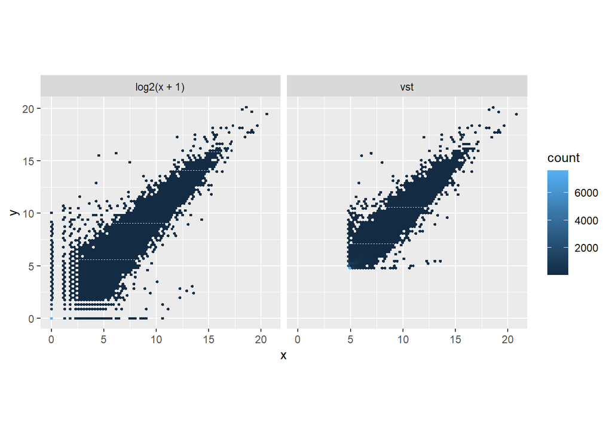

```r
library("dplyr")
library("ggplot2")

dds <- estimateSizeFactors(dds)

df <- bind_rows(
  as_data_frame(log2(counts(dds, normalized=TRUE)[, 1:2]+1)) %>%
         mutate(transformation = "log2(x + 1)"),
  as_data_frame(assay(vsd)[, 1:2]) %>% mutate(transformation = "vst"))
colnames(df)[1:2] <- c("x", "y")

ggplot(df, aes(x = x, y = y)) + geom_hex(bins = 80) +
  coord_fixed() + facet_grid( . ~ transformation)
```

3.6.3 Sample distances

```r
sampleDists <- dist(t(assay(vsd)))
```

Heatmap

[output not shown]

```
## Also defined by 'hexbin'
```

[output not shown]

```
## Also defined by 'hexbin'
```

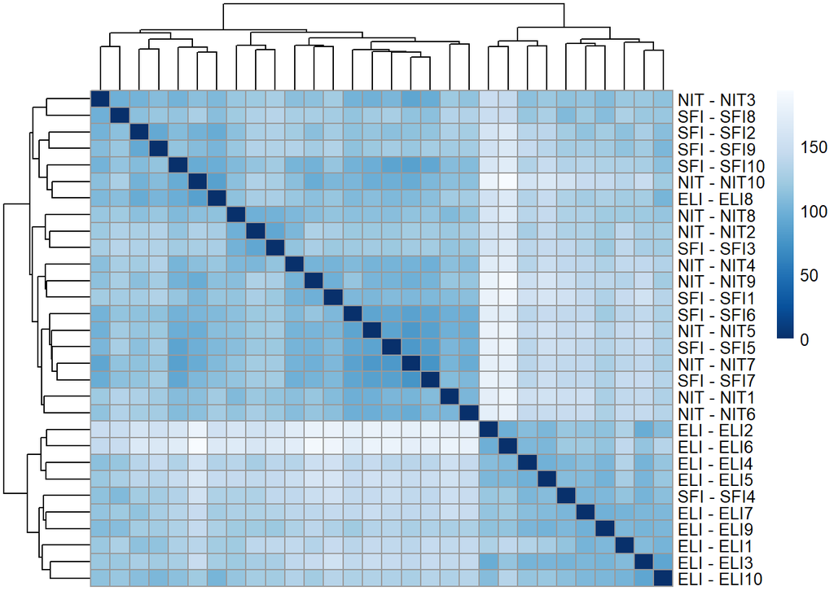

```r
library("pheatmap")
library("RColorBrewer")

sampleDistMatrix <- as.matrix( sampleDists )
rownames(sampleDistMatrix) <- paste( vsd$type, vsd$muestra, sep = " - " )
colnames(sampleDistMatrix) <- NULL
colors <- colorRampPalette( rev(brewer.pal(9, "Blues")) )(255)
pheatmap(sampleDistMatrix,
         clustering_distance_rows = sampleDists,
         clustering_distance_cols = sampleDists,
         col = colors)
```

PCA plots

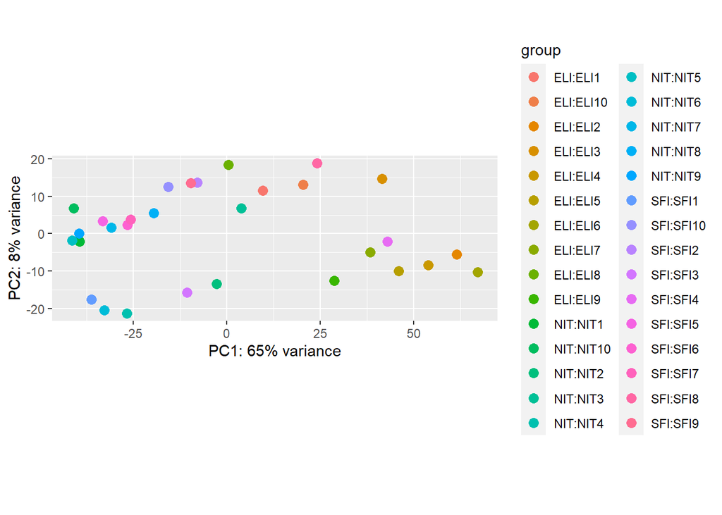

```r
plotPCA(vsd, intgroup  = c("type","muestra"))
```

3.7 Differential Expression Analysis

```r
dds <- DESeq(dds, parallel =TRUE)
```

```
## -- replacing outliers and refitting for 239 genes
## -- DESeq argument 'minReplicatesForReplace' = 7
## -- original counts are preserved in counts(dds)
```

```r
resNITSFI <- results(dds, contrast=c("type","NIT","SFI"))
resNITSFI
```

```
## log2 fold change (MLE): type NIT vs SFI
## Wald test p-value: type NIT vs SFI
## DataFrame with 40282 rows and 6 columns
##                            baseMean     log2FoldChange             lfcSE
##                           <numeric>          <numeric>         <numeric>
## ENSG00000223972.4  2.55891141932088 -0.130602351058366 0.722203194542501
## ENSG00000227232.4  650.020573860835   0.20559782730599 0.209601720542491
## ENSG00000243485.2  1.39568977318255 -0.272928260841741 0.681355643626261
## ENSG00000237613.2  1.54582254967803  0.638110661525741 0.785211204373539
## ENSG00000268020.2 0.877952243615327  0.378792936673179  1.10678217128253
## ...                             ...                ...               ...
## ENSG00000198695.2   65691.989122475  0.252245879648773 0.559188795213991
## ENSG00000210194.1  28.6325890368327 0.0900070351755318 0.828620379574144
## ENSG00000198727.2  421042.563792295  0.460219533500952 0.287923583506693
## ENSG00000210195.2 0.688168821888087  0.854009866586685  1.12820528448829
## ENSG00000210196.2  2.15320461196651  0.837089958999423 0.839441780261269
##                                 stat            pvalue              padj
##                            <numeric>         <numeric>         <numeric>
## ENSG00000223972.4 -0.180838788924354 0.856494115862887 0.999882277193175
## ENSG00000227232.4  0.980897612738394  0.32664323485174 0.991757258062164
## ENSG00000243485.2 -0.400566522630065 0.688739297339389 0.999420583780402
## ENSG00000237613.2  0.812661176982111 0.416412345810424 0.992837419683837
## ENSG00000268020.2  0.342247053215753  0.73216497752395                NA
## ...                              ...               ...               ...
## ENSG00000198695.2  0.451092514384598 0.651922872559956 0.999420583780402
## ENSG00000210194.1   0.10862276308216 0.913501705253222 0.999882277193175
## ENSG00000198727.2   1.59840860514385 0.109952070780926 0.910759897319391
## ENSG00000210195.2  0.756963185980847 0.449071918283742                NA
## ENSG00000210196.2  0.997198350955186 0.318668241244526 0.991319596856409
```

```r
res <- resNITSFI

#resNITELI <- results(dds, contrast=c("type","NIT","ELI"))
#resNITELI

#resSFIELI <- results(dds, contrast=c("type","SFI","ELI"))
#resSFIELI

table(resNITSFI$padj < 0.05)
```

```
##
## FALSE  TRUE
## 29323    25
```

```r
# genes con un p valor ajustado < 0.1 (consideramos )
sum(resNITSFI$padj < 0.1, na.rm=TRUE)
```

```
## [1] 89
```

```r
resSig <- subset(resNITSFI, padj < 0.1)
head(resSig[ order(resSig$log2FoldChange), ])
```

```
## log2 fold change (MLE): type NIT vs SFI
## Wald test p-value: type NIT vs SFI
## DataFrame with 6 rows and 6 columns
##                           baseMean    log2FoldChange            lfcSE
##                          <numeric>         <numeric>        <numeric>
## ENSG00000110680.8 1724.65665540506 -6.46453582185838 1.29699566433712
## ENSG00000211672.2  33.523695870013 -5.97866884318609 1.43091435916977
## ENSG00000270999.1 12.5948698688853 -5.49019300626217 1.16360380595612
## ENSG00000253998.2 85.1843811146349 -5.45443206492128  1.1022991199416
## ENSG00000211685.2 996.163765765328  -5.3222930262173  1.2254774196669
## ENSG00000254709.2 95.1695474081512 -5.26934486491841 1.14395052466833
##                                stat               pvalue                padj
##                           <numeric>            <numeric>           <numeric>
## ENSG00000110680.8 -4.98423857504746 6.22062875501956e-07 0.00549471702459938
## ENSG00000211672.2 -4.17821570164057  2.9380495065192e-05  0.0410599413892027
## ENSG00000270999.1  -4.7182666283486 2.37862620455614e-06 0.00872599023141422
## ENSG00000253998.2 -4.94823225950709 7.48905141692706e-07 0.00549471702459938
## ENSG00000211685.2  -4.3430363879442 1.40526847424127e-05  0.0257761369887705
## ENSG00000254709.2 -4.60626989654659 4.09956233462795e-06  0.0133682172662957
```

3.8 plotting results 3.8.1 counts plots

```
## geom_path: Each group consists of only one observation. Do you need to adjust
## the group aesthetic?
```

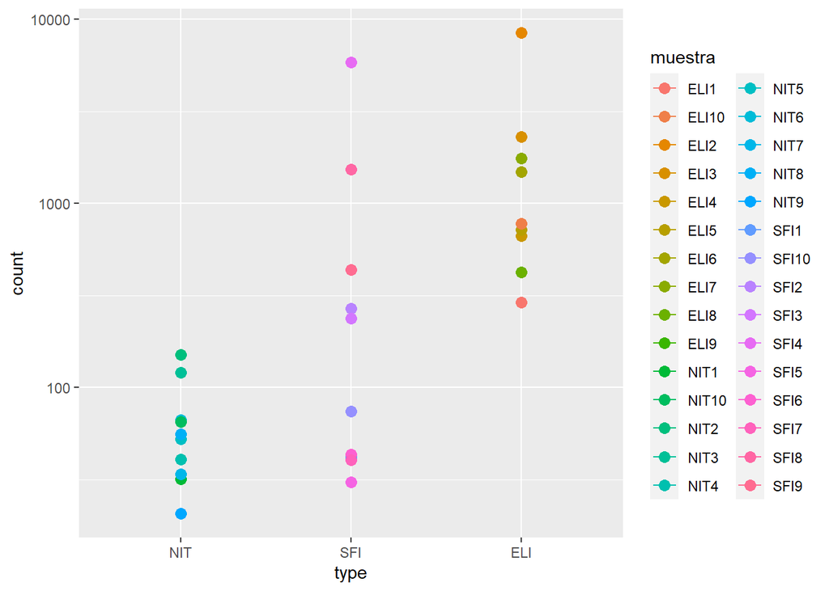

```r
topGene <- rownames(res)[which.min(res$padj)]

library("ggbeeswarm")

geneCounts <- plotCounts(dds, gene = topGene, intgroup = c("type","muestra"),returnData = TRUE)
ggplot(geneCounts, aes(x = type, y = count, color = muestra, group = muestra)) +
  scale_y_log10() + geom_point(size = 3) + geom_line()
```

3.8.2 MA-Plot

```r
library("apeglm")
resultsNames(dds)
```

```
## [1] "Intercept"       "type_SFI_vs_NIT" "type_ELI_vs_NIT"
```

```r
res <- lfcShrink(dds, coef="type_SFI_vs_NIT", type="apeglm")
```

```
## using 'apeglm' for LFC shrinkage. If used in published research, please cite:
##     Zhu, A., Ibrahim, J.G., Love, M.I. (2018) Heavy-tailed prior distributions for
##     sequence count data: removing the noise and preserving large differences.
##     Bioinformatics. https://doi.org/10.1093/bioinformatics/bty895
```

```r
class(res)
```

```
## [1] "DESeqResults"
## attr(,"package")
## [1] "DESeq2"
```

```r
colnames(res)
```

```
## [1] "baseMean"       "log2FoldChange" "lfcSE"          "pvalue"
## [5] "padj"
```

```r
summary(res)
```

```
##
## out of 40282 with nonzero total read count
## adjusted p-value < 0.1
## LFC > 0 (up)       : 85, 0.21%
## LFC < 0 (down)     : 4, 0.0099%
## outliers [1]       : 0, 0%
## low counts [2]     : 10934, 27%
## (mean count < 1)
## [1] see 'cooksCutoff' argument of ?results
## [2] see 'independentFiltering' argument of ?results
```

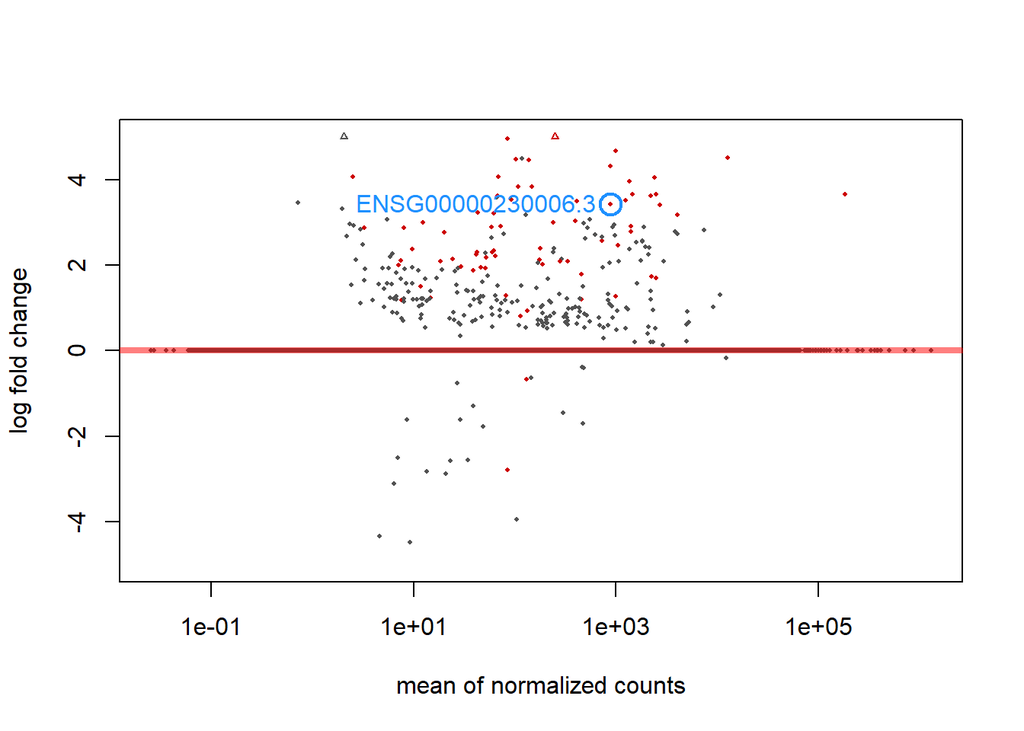

```r
plotMA(res, ylim = c(-5, 5))

plotMA(res, ylim = c(-5,5))
topGene <- rownames(res)[which.min(res$padj)]
with(res[topGene, ], {
  points(baseMean, log2FoldChange, col="dodgerblue", cex=2, lwd=2)
  text(baseMean, log2FoldChange, topGene, pos=2, col="dodgerblue")
})
```

3.8.3 Gene clustering

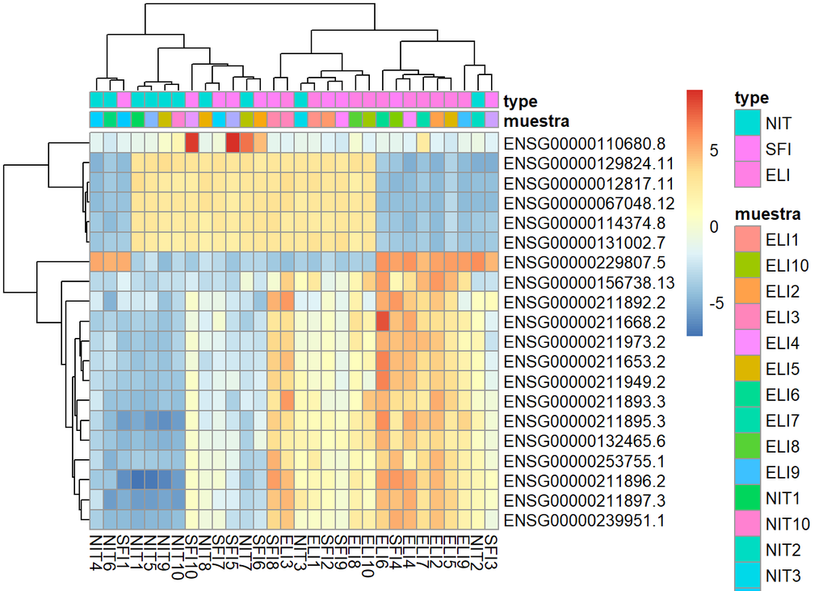

```r
library("genefilter")
topVarGenes <- head(order(rowVars(assay(vsd)), decreasing = TRUE), 20)

mat  <- assay(vsd)[topVarGenes, ]
mat  <- mat - rowMeans(mat)
anno <- as.data.frame(colData(vsd)[, c("muestra","type")])
pheatmap(mat, annotation_col = anno)
```

3.8.4 Ploting fold changes in genomic space